[figure not shown]

### 1) Situação geral do país

#### 1.1) Identificação das áreas atingidas por queimadas entre 17/03 a 23/03

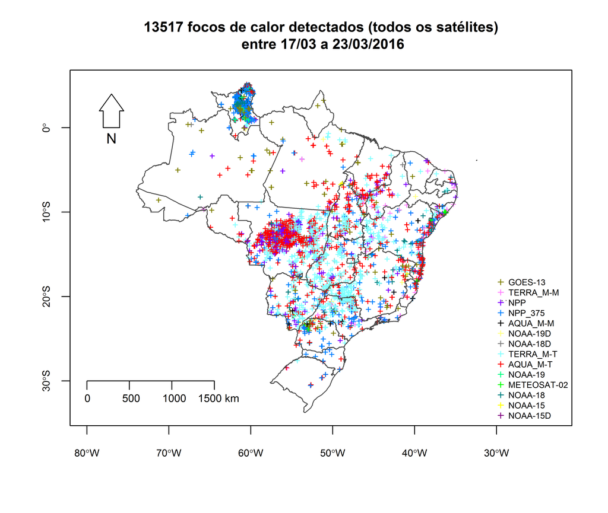

#### 1.2) Quantidade de Focos de calor detectados entre 17/03 a 23/03 (Satélite de Referência) em áreas de federais (Terras Indígenas, Assentamentos Rurais e Unidades de Conservação - Proteção Integral e Uso sustentável)

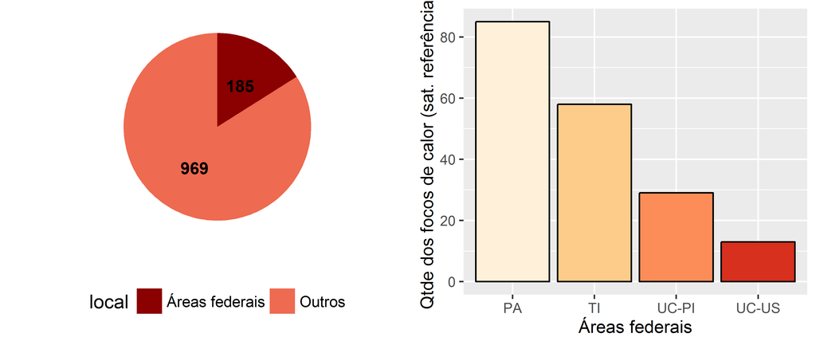

#### 2.1) Comparação anual dos focos de calor detectados no Brasil

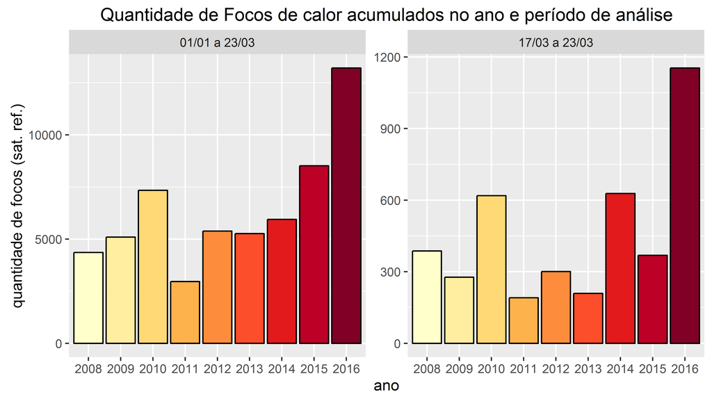

#### 2.2) Mapas de densidade de focos de calor (Kernel)

- No acumulado deste ano (de 01/01 a 23/03)

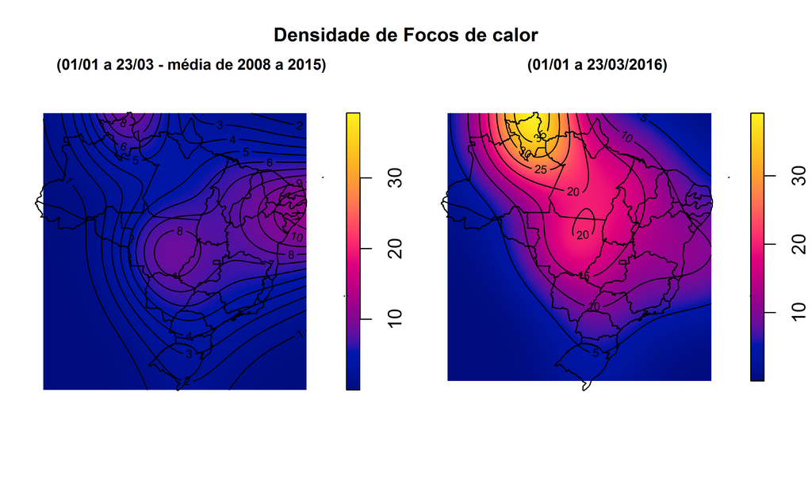

- No período de 17/03 a 23/03

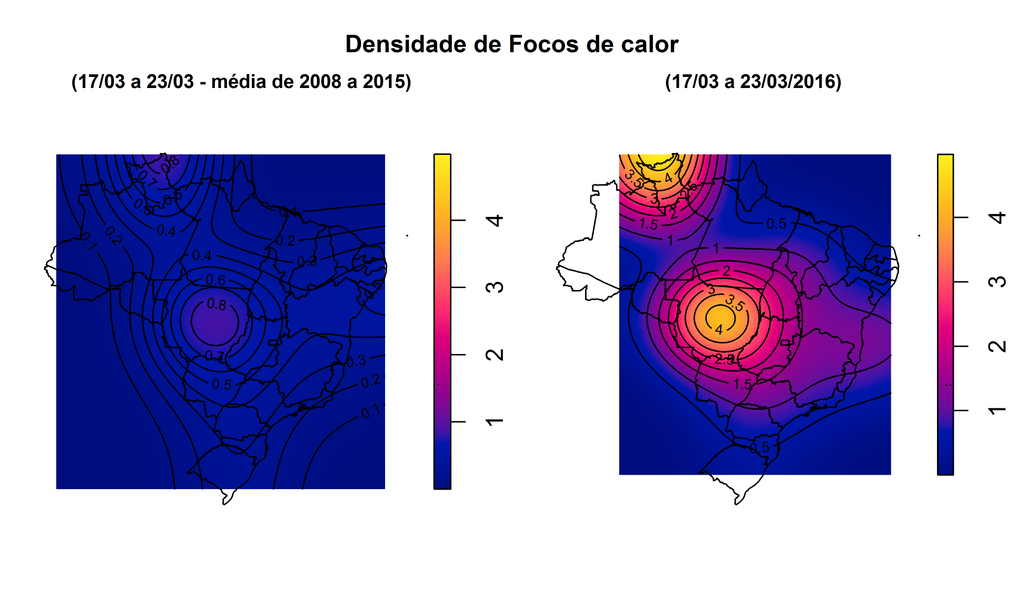

#### 2.3) Comparação por estado da quantidade de focos de calor detectados

- No acumulado do ano (de 01/01 a 23/03)

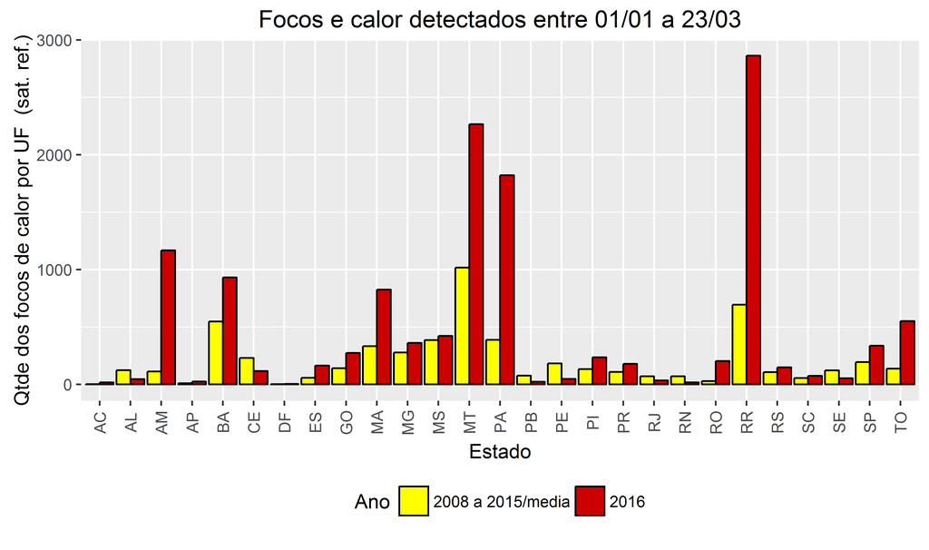

- No período de 17/03 a 23/03

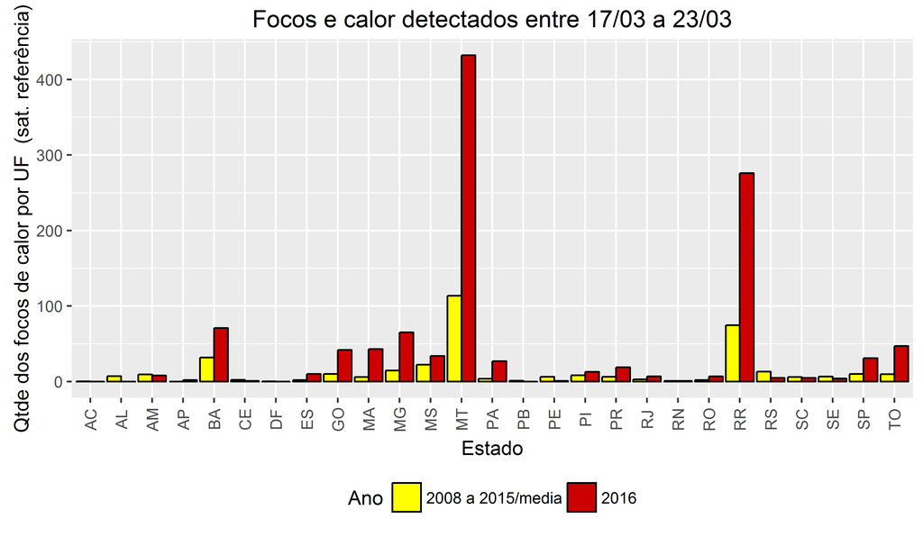

#### 2.4) Municípios mais atingidos por queimadas e incêndios florestais

- Quantidade de focos de calor (sat. ref.) detectados nos municípios no acumulado do ano e no período de análise (20 com mais ocorrências)

| Município | Qtde focos (01/01 a 23/03) |  |  | Município | Qtde focos (17/03 a 23/03) |
| --- | --- | --- | --- | --- | --- |
| Caracaraí-RR | 754 |  |  | Mucajaí-RR | 106 |
| Barcelos-AM | 601 |  |  | Caracaraí-RR | 62 |
| Rorainópolis-RR | 410 |  |  | Nova Maringá-MT | 43 |
| Mucajaí-RR | 408 |  |  | Nova Ubiratã-MT | 30 |
| Iracema-RR | 276 |  |  | Brasnorte-MT | 29 |
| Caroebe-RR | 183 |  |  | Alto Alegre-RR | 25 |
| Santarém-PA | 161 |  |  | Sorriso-MT | 24 |
| Monte Alegre-PA | 134 |  |  | Santa Carmem-MT | 23 |
| Nova Maringá-MT | 119 |  |  | Nova Mutum-MT | 20 |
| Nova Ubiratã-MT | 117 |  |  | Iracema-RR | 18 |
| Cantá-RR | 113 |  |  | Amajari-RR | 17 |
| Porto de Moz-PA | 110 |  |  | Feliz Natal-MT | 17 |
| Brasnorte-MT | 105 |  |  | Uiramutã-RR | 16 |
| Alenquer-PA | 100 |  |  | Canarana-MT | 14 |
| Amajari-RR | 98 |  |  | Gaúcha do Norte-MT | 14 |
| Bonfim-RR | 98 |  |  | Querência-MT | 13 |
| Canavieiras-BA | 97 |  |  | Campo Novo do Parecis-MT | 12 |
| Paranatinga-MT | 97 |  |  | Paranatinga-MT | 12 |
| Boa Vista-RR | 93 |  |  | São Félix do Araguaia-MT | 12 |
| Alto Alegre-RR | 91 |  |  | Santa Rita do Trivelato-MT | 11 |

### 3) Detecção de focos nas áreas federais

#### 3.1) Áreas Federais com Brifgadas Prevfogo/Ibama (BRIFs)

- Focos nas áreas das BRIFs no período de 17/03 a 23/03

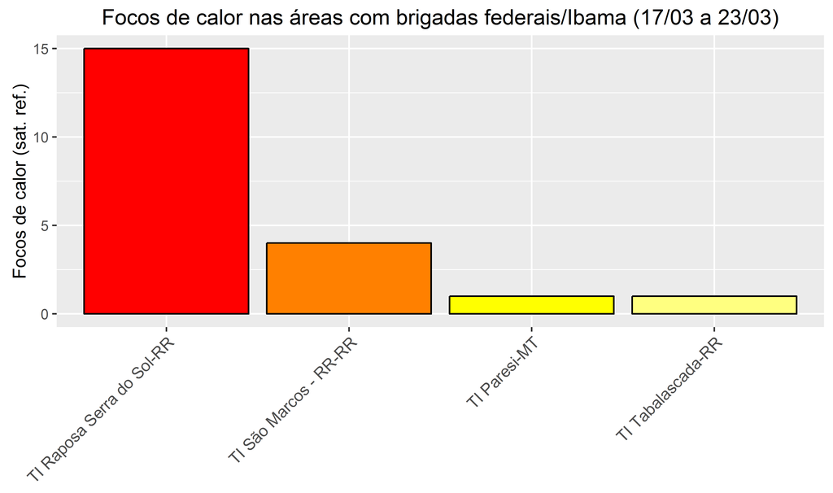

- Focos nas áreas das BRIFs no acumulado do ano e no período de 17/03 a 23/03

| Local | Qtde Focos (01/01 a 23/03) |  |  | Local | Qtde Focos (17/03 a 23/03) |
| --- | --- | --- | --- | --- | --- |
| TI Raposa Serra do Sol-RR | 133 |  |  | TI Raposa Serra do Sol-RR | 15 |
| TI São Marcos - RR-RR | 60 |  |  | TI São Marcos - RR-RR | 4 |
| TI Paresi-MT | 9 |  |  | TI Paresi-MT | 1 |
| TI Utiariti-MT | 8 |  |  | TI Tabalascada-RR | 1 |
| TI Araçá-RR | 7 |  |  |  |  |
| TI Parque do Araguaia-TO | 6 |  |  |  |  |
| PDS SERRA AZUL-PA/ST | 4 |  |  |  |  |
| TI Bacurizinho-MA | 4 |  |  |  |  |
| TI Tabalascada-RR | 3 |  |  |  |  |
| PA CAMPO VERDE-PA/ST | 2 |  |  |  |  |
| PA CAMPOS DO POPÓ-PA/ST | 2 |  |  |  |  |
| PA MARIPÃ?-PA/ST | 2 |  |  |  |  |
| PA MATUPI-AM | 2 |  |  |  |  |
| PA NILSON CAMPOS-RO | 2 |  |  |  |  |
| PAE SANTA QUITÉRIA-AC | 2 |  |  |  |  |
| TI Kraolandia-TO | 2 |  |  |  |  |
| TI Parque do Xingu-MT | 2 |  |  |  |  |
| PA CALMARIA II-PA/BL | 1 |  |  |  |  |
| PA MACHADINHO-RO | 1 |  |  |  |  |
| PA SANTA JULIA-PA/ST | 1 |  |  |  |  |
| PAE REGIAO DOS LAGOS-PA/ST | 1 |  |  |  |  |
| PDS BORDOLÃNDIA-MT | 1 |  |  |  |  |
| PIC ITAITUBA-PA/ST | 1 |  |  |  |  |
| Quilombo Kalungas-GO | 1 |  |  |  |  |
| TI Coroa Vermelha-BA | 1 |  |  |  |  |
| TI Serra da Moça-RR | 1 |  |  |  |  |
| TI Xerente-TO | 1 |  |  |  |  |

#### 3.2) Focos de calor em Unidades de Conservação Federais de Proteção Integral e Uso sustentável de 17/03 a 23/03 (20 com mais ocorrências)

| Unidades de Conservação (PI) | Qtde focos |  | Unidades de Conservação (US) | Qtde focos |
| --- | --- | --- | --- | --- |
| PARQUE NACIONAL SERRA DA MOCIDADE-AM/RR | 20 |  | FLORESTA NACIONAL DE RORAIMA-AM/RR | 7 |
| ESTACAO ECOLOGICA SERRA GERAL DO TOCANTINS-BA/TO | 3 |  | RESERVA EXTRATIVISTA DE CASSURUBÁ-BA | 3 |
| ESTAÇÃO ECOLÓGICA DE CARACARAÍ-RR | 1 |  | RESERVA EXTRATIVISTA VERDE PARA SEMPRE-PA | 2 |
| PARQUE NACIONAL DAS NASCENTES DO RIO PARNAIBA-MA/PI/BA | 1 |  | ÁREA DE PROTEÇÃO AMBIENTAL DA BACIA DO RIO SÃO JOÃO/MICO-LEÃO-DOURADO-RJ | 1 |
| PARQUE NACIONAL DO MONTE RORAIMA-RR | 1 |  |  |  |
| PARQUE NACIONAL DO VIRUÁ-RR | 1 |  |  |  |
| PARQUE NACIONAL E HISTÓRICO DO MONTE PASCOAL-BA | 1 |  |  |  |
| PARQUE NACIONAL GRANDE SERTÃO VEREDAS-BA/MG | 1 |  |  |  |

#### 3.3) Focos de calor em Terras Indígenas e Assentamentos Rurais de 17/03 a 23/03 (20 com mais ocorrências)

| Terras Indígenas | Qtde focos |  | Assentamentos Rurais | Qtde focos |
| --- | --- | --- | --- | --- |
| TI Raposa Serra do Sol-RR | 15 |  | PA SAMAUMA-RR | 19 |
| TI Yanomami-AM/RR | 15 |  | PA PAREDÃO-RR | 11 |
| TI São Marcos - RR-RR | 4 |  | PA VILA NOVA-RR | 7 |
| TI Manoa/Pium-RR | 3 |  | PA TEPEQUÉM-RR | 5 |
| TI Manoki-MT | 3 |  | PA AJARANI-RR | 4 |
| TI Arroio-Korá-MS | 2 |  | PA JAPÃO-RR | 4 |
| TI Canauanim-RR | 2 |  | PA MARANHÃO-RR | 4 |
| TI Porquinhos dos Kanela Apãnjekra-MA | 2 |  | PA BOM JESUS-RR | 3 |
| TI Umutina-MT | 2 |  | NA-TO | 2 |
| TI Aldeia Velha-BA | 1 |  | PA AMAJARI-RR | 2 |
| TI Barra Velha-BA | 1 |  | PA CUJUBIM-RR | 2 |
| TI Barra Velha do Monte Pascoal-BA | 1 |  | PDS LIBERDADE-PA | 2 |
| TI Cué Cué/ Marabitanas-AM | 1 |  | BR-080-MT | 1 |
| TI Itixi Mitari-AM | 1 |  | PA BOM SUCESSO-RR | 1 |
| TI Maxacali-MG | 1 |  | PA CANSANÇÃO-PI | 1 |
| TI Menkü-MT | 1 |  | PA CASTANHEIRA-RR | 1 |
| TI Moskow-RR | 1 |  | PA CAXIAS-RR | 1 |
| TI Paresi-MT | 1 |  | PA COM CULTIVO DE ESPECIES FLORESTAIS CELSO FURTADO-PR | 1 |
| TI Tabalascada-RR | 1 |  | PA INTEGRAÇÃO-RR | 1 |
|  |  |  | PA MASSARANDUBA-RR | 1 |

### 4) Informações sobre o clima (informações sugeridas)

[Risco de fogo e meteorologia/Inpe](http://www.inpe.br/queimadas/abasFogo.php)

[Previsão climática/Inpe](http://clima1.cptec.inpe.br/)

[Precipitação acumulada/Inmet](http://www.inmet.gov.br/portal/index.php?r=tempo2/mapasPrecipitacao)

[Previsão de precipitação futura/Inmet](http://www.inmet.gov.br/vime/)

[Portal do Inmet](http://www.inmet.gov.br)